# Load_and_transform_images_self_driving_Udacity (7)

[figure not shown]

M2.879 · TFM - Área 2 - Aula 1

2023-2 · Máster universitario en Ciencia de datos (*Data science*)

Estudios de Informática, Multimedia y Telecomunicación

# **AVANCES PRODUCTO TFM EN CIENCIA DE DATOS**

Título: **CSNN y Sostenibilidad en Conducción Autónoma**

Presentado por: **Andres Ricardo Sanabria Garay**

Tutor: **Raúl Parada Medina**

# Cargando y transformando datos de conducción autonoma para entrenar redes neuronales

Con el objetivo de preparar los insumos que se utilizarán en el entrenamiento de las Spiking Neural Netwoks (SNN) para conducción autonoma midiendo la ecoeficiencia del proceso. Se deben realizar varias aclaraciones:

En primer lugar, se parte del conjunto de datos empleado por Fernando Sevilla Martínez en su trabajo de Master Universitario en Ciencia de Datos de la UOC, titulado: "*Conducción autónoma mediante redes convolucionales y clonación del comportamiento con Unity y Udacity*" presentado en junio de 2022 y cuyo tutor fue Raúl Parada Medina.

Buena parte del código que se emplea en esta sección esta inspirado en el trabajo de Sevilla Martínez.

En las siguientes secciones se realizará la carga de los datos, el análisis de estos y la trasformación de los mismos

## Carga de datos

Con el propósito de aprovechar la potencia computacional disponible en Google Colab, esta plataforma será la empleada para cargar, analizar y transformar el conjunto de imágenes que se utilizarán en el entrenamiento de las redes neuronales.

Para ello iniciamos con el montaje del Drive. Esto permite que el entorno de Colab acceda a los archivos almacenados en Google Drive, haciendo que los datos sean accesibles directamente desde los Notebooks de Colab.

```python
# Mounting Google Drive

from google.colab import drive
drive.mount('/content/drive')
```

El siguiente código descomprime el archivo ZIP que contiene las imágenes de entrenamiento que se usarán para entrenar un la red neuronal. Esto se hace extrayendo el archivo en un directorio específico dentro del entorno de Colab.

```python
%%capture
!unzip "/content/drive/MyDrive/UOC/TFM/Dataset/TrainImagesTFM_1_2.zip" -d "/content"
```

Con el propósito de mantener el código organizado y reusable vamos a utilizar funciones, en este caso definimos una función que toma como entrada la ruta del archivo csv y devuelve un DataFrame bien estructurado con las columnas renombradas, como lo hizo Sevilla Martínez.

```python
import pandas as pd

def load_driving_data(csv_file_path):
    """
    Carga los datos de conducción desde un archivo CSV y retorna un DataFrame.

    Parámetros:
        csv_file_path (str): La ruta al archivo CSV que contiene los datos de conducción.

    Retorna:
        DataFrame: Un DataFrame de pandas con las columnas renombradas adecuadamente.
    """
    # Carga el archivo CSV
    data = pd.read_csv(csv_file_path)

    # Renombra las columnas para mejor claridad
    data.columns = [
        'center_image',  # Ruta de la imagen central
        'left_image',    # Ruta de la imagen izquierda
        'right_image',   # Ruta de la imagen derecha
        'steering_angle',  # Ángulo del volante
        'throttle',        # Aceleración
        'brake',           # Frenado
        'speed'            # Velocidad del vehículo
    ]

    return data

# Ruta al archivo descomprimido en /content
csv_file_path = '/content/TrainImagesTFM_1_2/driving_log.csv'
driving_data = load_driving_data(csv_file_path)
print(driving_data.head())
```

```
                                        center_image  \
0  /Users/fernandosevilla/UOC/UOC Repositorio asi...
1  /Users/fernandosevilla/UOC/UOC Repositorio asi...
2  /Users/fernandosevilla/UOC/UOC Repositorio asi...
3  /Users/fernandosevilla/UOC/UOC Repositorio asi...
4  /Users/fernandosevilla/UOC/UOC Repositorio asi...

                                          left_image  \
0  /Users/fernandosevilla/UOC/UOC Repositorio asi...
1  /Users/fernandosevilla/UOC/UOC Repositorio asi...
2  /Users/fernandosevilla/UOC/UOC Repositorio asi...
3  /Users/fernandosevilla/UOC/UOC Repositorio asi...
4  /Users/fernandosevilla/UOC/UOC Repositorio asi...

                                         right_image  steering_angle  \
0  /Users/fernandosevilla/UOC/UOC Repositorio asi...             0.0
1  /Users/fernandosevilla/UOC/UOC Repositorio asi...             0.0
2  /Users/fernandosevilla/UOC/UOC Repositorio asi...             0.0
3  /Users/fernandosevilla/UOC/UOC Repositorio asi...             0.0
4  /Users/fernandosevilla/UOC/UOC Repositorio asi...             0.0

   throttle  brake     speed
0       0.0    0.0  0.000007
1       0.0    0.0  0.000008
2       0.0    0.0  0.000008
3       0.0    0.0  0.000009
4       0.0    0.0  0.000007
```

## Ajustes en el dataframe

Para utilizar las imagenes que fueron extraídas en el content de Colab, es necesario como lo hizo Sevilla Martínez extraer el nombre del archivo en lugar de toda la ruta. Vamos a hacerlo mediante el siguiente código

```python
def simplify_image_path(dataframe, columns):
    """
    Modifica las rutas de las imágenes en el DataFrame para dejar solo los nombres de archivo.

    Parámetros:
        dataframe (pd.DataFrame): DataFrame que contiene las rutas completas de las imágenes.
        columns (list): Lista de nombres de columnas que contienen las rutas de las imágenes.

    Retorna:
        pd.DataFrame: DataFrame actualizado con solo los nombres de archivo en las columnas especificadas.
    """
    for column in columns:
        # Extraemos solo el nombre del archivo de cada ruta
        dataframe[column] = dataframe[column].apply(lambda x: x.split('/')[-1])
    return dataframe

# Nombres de las columnas de imágenes
image_columns = ['center_image', 'left_image', 'right_image']

# Aplicando la función al DataFrame
driving_data = simplify_image_path(driving_data, image_columns)

# Mostrar las primeras filas del DataFrame para verificar los cambios
print(driving_data.head())
```

```
                         center_image                        left_image  \
0  center_2022_04_30_19_01_57_321.jpg  left_2022_04_30_19_01_57_321.jpg
1  center_2022_04_30_19_01_57_389.jpg  left_2022_04_30_19_01_57_389.jpg
2  center_2022_04_30_19_01_57_471.jpg  left_2022_04_30_19_01_57_471.jpg
3  center_2022_04_30_19_01_57_538.jpg  left_2022_04_30_19_01_57_538.jpg
4  center_2022_04_30_19_01_57_621.jpg  left_2022_04_30_19_01_57_621.jpg

                         right_image  steering_angle  throttle  brake  \
0  right_2022_04_30_19_01_57_321.jpg             0.0       0.0    0.0
1  right_2022_04_30_19_01_57_389.jpg             0.0       0.0    0.0
2  right_2022_04_30_19_01_57_471.jpg             0.0       0.0    0.0
3  right_2022_04_30_19_01_57_538.jpg             0.0       0.0    0.0
4  right_2022_04_30_19_01_57_621.jpg             0.0       0.0    0.0

      speed
0  0.000007
1  0.000008
2  0.000008
3  0.000009
4  0.000007
```

## Análisis de los datos del log

Un paso importante es realizar el análisis de los datos que contiene el log de imágenes y datos obtenidos del vehículo. Primero algunas descripción sobre estos:

1.Descripción estadística de las columnas numéricas del dataframe

```python
print(driving_data.describe())
```

```
       steering_angle      throttle         brake         speed
count    12945.000000  12945.000000  12945.000000  12945.000000
mean        -0.010260      0.474558      0.010656     23.228469
std          0.293935      0.466944      0.095999      7.111932
min         -1.000000      0.000000      0.000000      0.000006
25%          0.000000      0.000000      0.000000     17.380540
50%          0.000000      0.351500      0.000000     24.917880
75%          0.000000      1.000000      0.000000     30.189880
max          1.000000      1.000000      1.000000     30.606040
```

Contamos con 12945 imágenes de cada una de las cámaras del vehículo para un total de 38835 imágenes

1. Verificación de valores nulos:

```python
print(driving_data.isnull().sum())
```

```
center_image      0
left_image        0
right_image       0
steering_angle    0
throttle          0
brake             0
speed             0
dtype: int64
```

No se identifican valores nulos

1. Visualización de la distribuciones

Utilizando bibliotecas como matplotlib y/o seaborn podemos visualizar las distribuciones de las variables

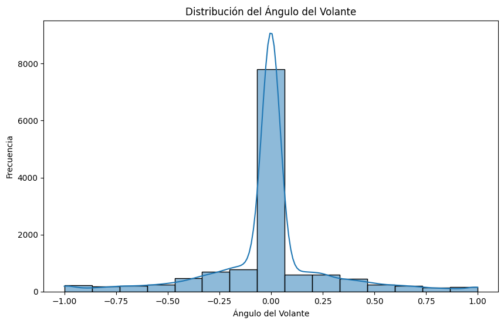

```python
import matplotlib.pyplot as plt
import seaborn as sns

# Histograma del ángulo del volante
plt.figure(figsize=(10, 6))
sns.histplot(driving_data['steering_angle'], kde=True)
plt.title('Distribución del Ángulo del Volante')
plt.xlabel('Ángulo del Volante')
plt.ylabel('Frecuencia')
plt.show()
```

A partir del histograma del ángulo del volante, podemos afirmar que en la información capturada en el simulador la mayor parte del tiempo el vehículo va en un camino relativamente recto.

1. Correlaciones entre variables

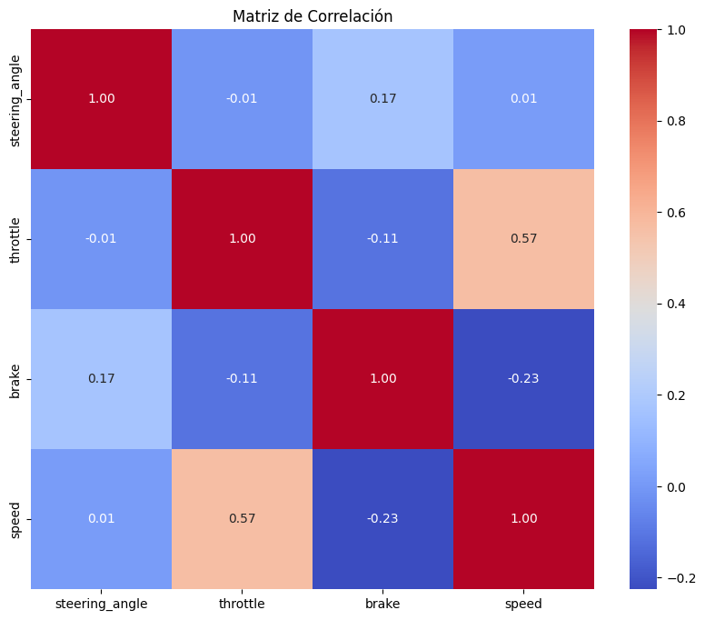

```python
# Seleccionamos solo las columnas numéricas
numeric_data = driving_data[['steering_angle', 'throttle', 'brake', 'speed']]

# Creamos la matriz de correlación
plt.figure(figsize=(10, 8))
sns.heatmap(numeric_data.corr(), annot=True, fmt=".2f", cmap='coolwarm')
plt.title('Matriz de Correlación')
plt.show()
```

La correlación directa más fuerte se presenta entre la aceleración y la velocidad como era de esperarse, a mayor aceleración mayor velocidad. La correlación inversa más fuerte es entre la frenada (brake) y la velocidad (speed), lo podemos ver como a mayor frenado menor velocidad.

## Carácterísticas de los datos de conducción

Recordemos que las imágenes del conjunto de datos se obtienen de un circuito simulado y con el objetivo de evitar overfitting tal como lo hace Sevilla Martínez se debe buscar que los datos de conducción de giros en ambas direcciones y en sentido recto sean similares por lo que procedemos a revisar esta distribución con el siguiente código

```python
def categorize_turns(data, angle_column):
    """
    Categoriza los ángulos de giro en un DataFrame y cuenta las ocurrencias de cada categoría.

    Parámetros:
        data (pd.DataFrame): DataFrame que contiene los datos de conducción.
        angle_column (str): Nombre de la columna en el DataFrame que contiene los ángulos del volante.

    Retorna:
        pd.Series: Conteo de ocurrencias de cada categoría de giro.
    """
    # Definir los límites y las etiquetas para las categorías de giro
    bins = [-float('inf'), -0.1, 0.1, float('inf')]
    labels = ['Left Turn', 'Straight', 'Right Turn']

    # Categorizar los ángulos usando pd.cut
    data['turn_category'] = pd.cut(data[angle_column], bins=bins, labels=labels)

    # Contar las ocurrencias de cada categoría
    turn_counts = data['turn_category'].value_counts()

    return turn_counts

# Uso de la función
turn_counts = categorize_turns(driving_data, 'steering_angle')
print(turn_counts)
```

```
turn_category
Straight      8066
Left Turn     2674
Right Turn    2205
Name: count, dtype: int64
```

Los resultados muestran, como lo afirmamos en el histograma de ángulo de giro, que la mayor cantidad de registros corresponden con situaciones de manejo en línea recta. Por tanto, vamos a replicar el número de registros de las categorías derecha e izquierda para equilibrar el número de registros

```python
def balance_data_by_replication(data, category_column, target_size=None):
    """
    Equilibra un DataFrame replicando registros en categorías menos representadas hasta alcanzar un tamaño objetivo.

    Parámetros:
        data (pd.DataFrame): DataFrame que contiene los datos a equilibrar.
        category_column (str): Nombre de la columna que contiene las categorías de datos.
        target_size (int, opcional): Número deseado de registros por categoría. Si no se especifica, se usará el tamaño de la categoría más grande.

    Retorna:
        pd.DataFrame: Un DataFrame equilibrado.
    """
    # Dividir el DataFrame por categoría
    categories = data[category_column].unique()
    subset_list = [data[data[category_column] == category] for category in categories]

    # Si no se proporciona un tamaño objetivo, usar el tamaño de la categoría más grande
    if not target_size:
        target_size = max(subset.shape[0] for subset in subset_list)

    # Replicar registros en cada subconjunto si es necesario
    balanced_subsets = [subset.sample(target_size, replace=True) if subset.shape[0] < target_size else subset for subset in subset_list]

    # Combinar todos los subconjuntos en un solo DataFrame
    balanced_data = pd.concat(balanced_subsets, ignore_index=True)

    return balanced_data

# Uso de la función
category_column = 'turn_category'
balanced_driving_data = balance_data_by_replication(driving_data, category_column)
print(balanced_driving_data['turn_category'].value_counts())
```

```
turn_category
Left Turn     8066
Straight      8066
Right Turn    8066
Name: count, dtype: int64
```

Con los registros duplicados conviene revisar nuevamente la distribución de los ángulos de giro en un histograma, como lo habíamos hecho previamente

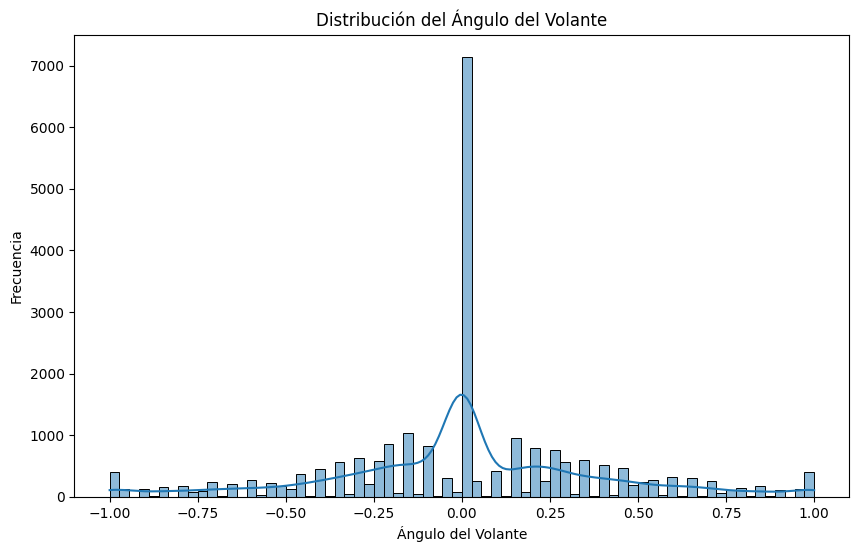

```python
# Histograma del ángulo del volante
plt.figure(figsize=(10, 6))
sns.histplot(balanced_driving_data['steering_angle'], kde=True)
plt.title('Distribución del Ángulo del Volante')
plt.xlabel('Ángulo del Volante')
plt.ylabel('Frecuencia')
plt.show()
```

A pesar de la replicación de registros, tal como lo evidenció Sevilla Martínez la mayor parte de registros continua con valores de ángulos cercanos a cero, por lo que siguiendo su trabajo eliminaremos registros con ángulos de giro próximos a cero o cero, con la siguiente adaptación de su código:

```python
import numpy as np

def calculate_samples_per_bin(df, steering_col, num_bins, percentile):
    """
    Calcula el número máximo de muestras por bin basado en un percentil dado.

    Args:
        df (pd.DataFrame): DataFrame que contiene los datos.
        steering_col (str): Columna de ángulos de dirección.
        num_bins (int): Número de bins para agrupar los datos.
        percentile (float): Percentil para calcular el límite de muestras por bin.

    Returns:
        int: Número de muestras por bin.
    """
    hist, _ = np.histogram(df[steering_col], bins=num_bins)
    max_samples = np.percentile(hist, percentile)
    return int(max_samples)

# Uso de la función
percentile = 90
num_bins = 25
max_samples_per_bin = calculate_samples_per_bin(balanced_driving_data, 'steering_angle', num_bins, percentile)
print("Número máximo de muestras por bin calculado:", max_samples_per_bin)
```

```
Número máximo de muestras por bin calculado: 1391
```

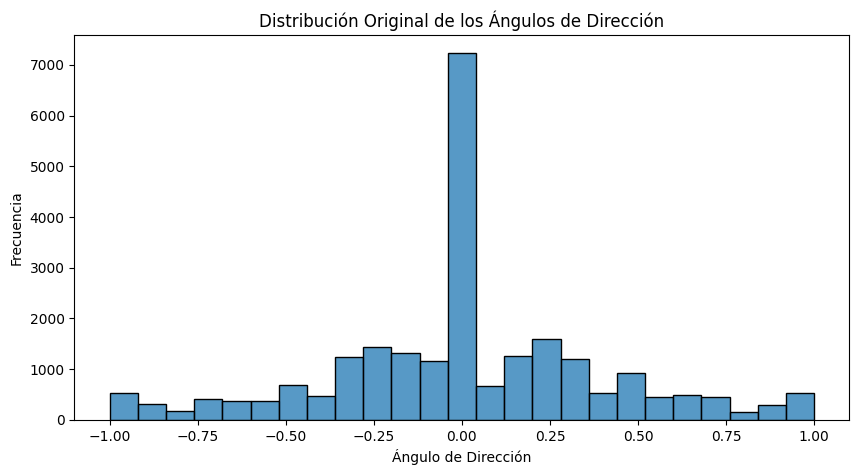

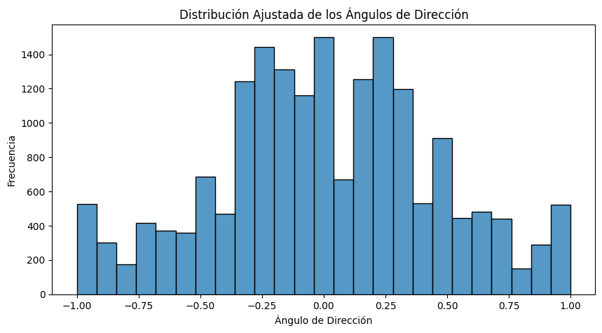

```python
from sklearn.utils import shuffle

def remove_samples(df, num_bins=25, samples_per_bin=1500, steering_col='steering_angle'):
    """
    Ajusta la distribución de los ángulos de dirección para que sea más uniforme limitando el número de muestras por bin.

    Argumentos:
        df (pd.DataFrame): DataFrame que contiene los datos del ángulo de dirección.
        num_bins (int): Número de bins para agrupar los datos.
        samples_per_bin (int): Número máximo de muestras permitidas por bin.
        steering_col (str): Nombre de la columna para los ángulos de dirección.

    Devuelve:
        pd.DataFrame: DataFrame ajustado con una distribución más uniforme de los ángulos de dirección.
    """
    df.reset_index(drop=True, inplace=True)
    hist, bins = np.histogram(df[steering_col], bins=num_bins)
    center = (bins[:-1] + bins[1:]) / 2

    # Visualización de la distribución original usando matplotlib y seaborn
    plt.figure(figsize=(10, 5))
    sns.histplot(df[steering_col], bins=num_bins, kde=False)
    plt.title("Distribución Original de los Ángulos de Dirección")
    plt.xlabel("Ángulo de Dirección")
    plt.ylabel("Frecuencia")
    plt.show()

    remove_list = []
    for j in range(num_bins):
        list_indices = []
        for i in range(len(df[steering_col])):
            if bins[j] <= df[steering_col].iloc[i] < bins[j + 1]:
                list_indices.append(i)
        list_indices = shuffle(list_indices)
        list_indices = list_indices[samples_per_bin:]
        remove_list.extend(list_indices)

    # Eliminar los índices seleccionados
    df.drop(df.index[remove_list], inplace=True)

    # Visualización de la distribución ajustada
    plt.figure(figsize=(10, 5))
    sns.histplot(df[steering_col], bins=num_bins, kde=False)
    plt.title("Distribución Ajustada de los Ángulos de Dirección")
    plt.xlabel("Ángulo de Dirección")
    plt.ylabel("Frecuencia")
    plt.show()

    return df

# Aplicar la función al conjunto de datos de conducción equilibrado
balanced_data_adjusted = remove_samples(balanced_driving_data)
```

Siguiendo la metodología propuesta por Sevilla Martínez incorporamos valores de offset a las imágenes de las cámaras derecha e izquierda

```python
import os

def load_img_steering(datadir, df):
    """
    Asocia cada imagen de las cámaras central, izquierda y derecha con un ángulo de giro ajustado.
    - Para la cámara central, se utiliza el ángulo directamente.
    - Para la cámara izquierda, se suma un offset para simular un giro más hacia la derecha.
    - Para la cámara derecha, se resta un offset para simular un giro más hacia la izquierda.

    Args:
        datadir (str): Ruta al directorio que contiene las imágenes.
        df (DataFrame): DataFrame que contiene los nombres de cada imagen y su ángulo de giro relacionado.

    Returns:
        tuple: Dos arrays, uno con las rutas de las imágenes y otro con los ángulos de giro ajustados.
    """
    image_path = []
    steering = []

    for i in range(len(df)):
        indexed_data = df.iloc[i]
        center, left, right = indexed_data[0], indexed_data[1], indexed_data[2]
        image_path.append(os.path.join(datadir, center.strip()))
        steering.append(float(indexed_data[3]))
        image_path.append(os.path.join(datadir, left.strip()))
        steering.append(float(indexed_data[3]) + 0.2)  # Offset para la cámara izquierda
        image_path.append(os.path.join(datadir, right.strip()))
        steering.append(float(indexed_data[3]) - 0.2)  # Offset para la cámara derecha

    return np.array(image_path), np.array(steering)

offset_data_adjust = load_img_steering("/content/TrainImagesTFM_1_2/IMG/", balanced_data_adjusted)
```

## Conjuntos de entrenamiento y prueba

Como lo hizo Sevilla Martinez esta listas sirven de entrada a otra función con la que se generan los conjuntos de entrenamiento y prueba como se muestra a continuación:

```python
from sklearn.model_selection import train_test_split


def trainValSample(dir, df):
    """
    Crea datos de entrenamiento y validación buscando en el directorio las imágenes del DataFrame.

    Argumentos:
        dir (str): Ruta al directorio donde se encuentran las imágenes.
        df (DataFrame): DataFrame con el nombre de la imagen a buscar.

    Devuelve:
        tuple: Retorna los caminos de las imágenes, ángulos de dirección, y divisiones de entrenamiento y validación.
    """
    # Asegúrate de que la ruta termine correctamente
    if not dir.endswith("/"):
        dir += "/"

    # Carga las imágenes y los ángulos de giro
    image_paths, steerings = load_img_steering(dir + "IMG/", df)

    # Divide los datos en conjuntos de entrenamiento y validación
    X_train, X_valid, y_train, y_valid = train_test_split(image_paths, steerings, test_size=0.2, random_state=42)

    # Imprime el resumen de las muestras
    print("Training Samples: {}\nValidation Samples: {}".format(len(X_train), len(X_valid)))
    print("Total Samples: {}".format(len(image_paths)))

    return image_paths, steerings, X_train, X_valid, y_train, y_valid

# Llamada a la función
# Suponiendo que 'balanced_data_adjusted' es el DataFrame y '/content/TrainImagesTFM_1_2/' es el directorio
image_paths, steerings, X_train, X_valid, y_train, y_valid = trainValSample("/content/TrainImagesTFM_1_2/", balanced_data_adjusted)
```

```
Training Samples: 44083
Validation Samples: 11021
Total Samples: 55104
```

## Técnicas de transformación y aumento de datos

Cada técnica tiene un propósito específico en como puede ayudar a mejorar el rendimiento del modelo al hacerlo más robusto frente a variaciones en datos nuevos o no vistos durante el entrenamiento.

A continuación replicaremos las técnicas empleadas en el trabajo de Sevilla Martínez con las respectivas adaptaciones a su código

```python
# Función para visualizar ejemplos de las transformaciones

def compare_images(original, transformed, title='Original and Transformed'):
    """
    Muestra dos imágenes lado a lado para comparación.

    Args:
        original: La imagen original.
        transformed: La imagen transformada.
        title: El título para la figura.
    """
    fig, axes = plt.subplots(1, 2, figsize=(10, 5))
    axes[0].imshow(original)
    axes[0].set_title('Original')
    axes[0].axis('off')  # Desactiva los ejes para mejor visualización

    axes[1].imshow(transformed)
    axes[1].set_title('Transformed')
    axes[1].axis('off')

    plt.suptitle(title)
    plt.show()
```

### Zoom

¿Qué hace? Hace zoom hacia dentro en la imagen.

¿Por qué usarlo? Simula el efecto de la cámara acercándose o alejándose de objetos. Esto es particularmente útil para modelos que deben detectar objetos a diferentes distancias.

Aquí, específicamente, se utiliza para escalar la imagen entre un rango de 1 (tamaño original) a 1.5 (un 50% más grande)

```python
import cv2
from imgaug import augmenters as iaa

def apply_zoom(image):
    """
    Aplica un aumento de escala (zoom) a la imagen.
    El zoom varía entre el tamaño original y un 50% más grande.

    Args:
        image: Una imagen en forma de un arreglo NumPy.

    Returns:
        La imagen con el zoom aplicado.
    """
    # Definir el transformador de zoom con imgaug
    zoom_transformer = iaa.Affine(scale=(1, 1.5))

    # Aplicar el transformador de zoom a la imagen
    zoomed_image = zoom_transformer.augment_image(image)

    return zoomed_image
```

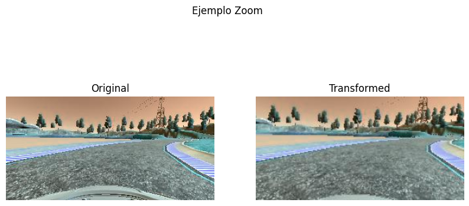

```python
# Ejemplo de la función apply_zoom aplicada sobre una imagen
imagen = cv2.imread('/content/TrainImagesTFM_1_2/IMG/center_2022_04_30_19_03_21_734.jpg')
ejemplo_zoom = apply_zoom(imagen)
resultado = compare_images(imagen, ejemplo_zoom, title='Ejemplo Zoom')
```

### Volteado de imágenes

¿Que hace? Voltea la imagen horizontalmente y ajusta el ángulo de giro correspondiente.

¿Por qué usarlo? Se utiliza generalmente para aumentar la cantidad de datos de entrenamiento y para enseñar al modelo a generalizar mejor sobre maniobras en ambas direcciones.

```python
def random_flip(image, steering_angle):
    """
    Voltea la imagen horizontalmente y ajusta el ángulo de giro correspondiente.

    Args:
        image: La imagen a voltear, como un arreglo de NumPy.
        steering_angle: El ángulo de giro asociado con la imagen.

    Returns:
        tuple: La imagen volteada y el nuevo ángulo de giro ajustado.
    """
    # Voltear la imagen horizontalmente
    flipped_image = cv2.flip(image, 1)

    # Ajustar el ángulo de giro
    flipped_steering_angle = -steering_angle

    return flipped_image, flipped_steering_angle
```

[figure not shown]

```python
# Ejemplo de la función random_flip aplicada sobre una imagen
imagen = cv2.imread(image_paths[10])
ejemplo_flip, angulo = random_flip(imagen,steerings[10])
resultado = compare_images(imagen, ejemplo_flip, title='Volteado Horizontal')
```

### Desplazamiento de imágenes

¿Que hace? Desplaza la imagen tanto vertical como horizontalmente.

¿Por qué usarlo? Es útil para simular la variación en la posición de la cámara y para enseñar al modelo a lidiar con desplazamientos leves de la perspectiva visual.

```python
def apply_pan(image):
    """
    Aplica un desplazamiento aleatorio (panning) a la imagen, tanto vertical como horizontalmente.

    Args:
        image: Una imagen en forma de un arreglo NumPy.

    Returns:
        La imagen desplazada.
    """
    # Definir el transformador de desplazamiento con imgaug
    pan_transformer = iaa.Affine(translate_percent={"x": (-0.1, 0.1), "y": (-0.1, 0.1)})

    # Aplicar el transformador de desplazamiento a la imagen
    panned_image = pan_transformer.augment_image(image)

    return panned_image
```

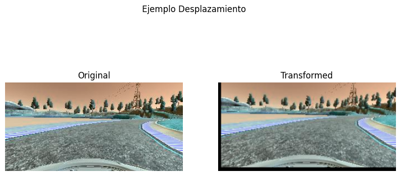

```python
# Ejemplo de la función apply_pan aplicada sobre una imagen
imagen = cv2.imread('/content/TrainImagesTFM_1_2/IMG/center_2022_04_30_19_03_21_734.jpg')
ejemplo_desplazamiento = apply_pan(imagen)
resultado = compare_images(imagen, ejemplo_desplazamiento, title='Ejemplo Desplazamiento')
```

### Modificación del brillo de las imágenes

¿Que hace? Ajusta el brillo de las imágenes.

¿Por qué usarla? Simula diferentes condiciones de iluminación

La siguiente función multiplica todos los pixeles de una imagen por un valor aleatorio lo que puede hacer que la imagen sea más clara u oscura

```python
def apply_random_brightness(image):
    """
    Modifica el brillo de la imagen de forma aleatoria usando imgaug.

    Args:
        image: Una imagen en forma de un arreglo NumPy.

    Returns:
        La imagen con el brillo modificado.
    """
    brightness_augmenter = iaa.Multiply((0.2, 1.6))
    brightened_image = brightness_augmenter.augment_image(image)

    return brightened_image
```

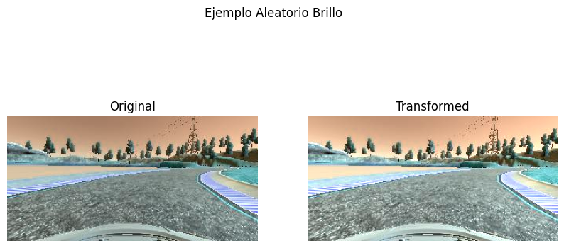

```python
# Ejemplo de la función apply_random_brightness aplicada sobre una imagen
imagen = cv2.imread('/content/TrainImagesTFM_1_2/IMG/center_2022_04_30_19_03_21_734.jpg')
ejemplo_ran_bright= apply_random_brightness(imagen)
resultado = compare_images(imagen, ejemplo_ran_bright, title='Ejemplo Aleatorio Brillo')
```

En el trabajo de Sevilla Martínez hay una segunda función asociada al brillo image_brighten, que usa OpenCV para convertir la imagen a espacio de color HSV, ajusta el canal de brillo (V) con un valor aleatorio y luego la convierte de vuelta a espacio de color RGB.

```python
def apply_image_brighten(image):
    """
    Ajusta el brillo de la imagen cambiando el valor en el espacio de color HSV.

    Args:
        image: Una imagen en forma de un arreglo NumPy.

    Returns:
        La imagen con el brillo ajustado.
    """
    # Convertir la imagen a espacio de color HSV
    hsv_image = cv2.cvtColor(image, cv2.COLOR_BGR2HSV)

    # Calcular el factor de brillo
    brightness = 0.25 + np.random.uniform()

    # Aplicar el factor de brillo al canal V
    hsv_image[:, :, 2] = hsv_image[:, :, 2] * brightness

    # Asegurarse de que los valores de V se mantengan en el rango adecuado
    hsv_image[:, :, 2] = np.clip(hsv_image[:, :, 2], 0, 255)

    # Convertir la imagen de vuelta a espacio de color RGB
    brightened_image = cv2.cvtColor(hsv_image, cv2.COLOR_HSV2BGR)

    return brightened_image
```

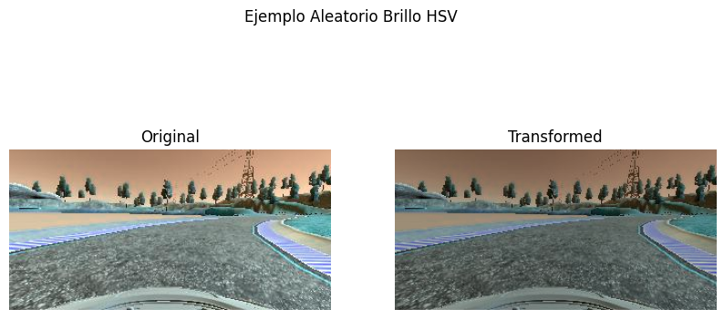

```python
# Ejemplo de la función apply_image_brighten aplicada sobre una imagen
imagen = cv2.imread('/content/TrainImagesTFM_1_2/IMG/center_2022_04_30_19_03_21_734.jpg')
ejemplo_hsv_bright= apply_image_brighten(imagen)
resultado = compare_images(imagen, ejemplo_hsv_bright, title='Ejemplo Aleatorio Brillo HSV')
```

### Creación de sombras

¿Que hace? Genera y añade sombras aleatorias a las imágenes

¿Por qué usarla? Puede mejorar la robustez del modelo a las variaciones de iluminación en las imágenes

```python
def apply_random_shadow(image):
    """
    Genera y añade una sombra aleatoria a la imagen para simular condiciones de iluminación variables.

    Args:
        image: Una imagen en forma de un arreglo NumPy.

    Returns:
        La imagen con una sombra aplicada.
    """
    # Altura, ancho y canales de la imagen
    IMAGE_HEIGHT, IMAGE_WIDTH, IMAGE_CHANNELS = image.shape

    # Crear una línea aleatoria desde donde se proyectará la sombra
    x1, y1 = IMAGE_WIDTH * np.random.rand(), 0
    x2, y2 = IMAGE_WIDTH * np.random.rand(), IMAGE_HEIGHT

    # Crear una máscara que simule la sombra
    xm, ym = np.mgrid[0:IMAGE_HEIGHT, 0:IMAGE_WIDTH]
    mask = np.zeros_like(image[:, :, 1])
    mask[((ym - y1) * (x2 - x1) - (y2 - y1) * (xm - x1)) > 0] = 1

    # Decidir aleatoriamente qué lado de la línea tendrá la sombra
    cond = mask == np.random.randint(2)
    s_ratio = np.random.uniform(low=0.2, high=0.5)

    # Convertir la imagen a espacio de color HLS y ajustar la saturación
    hls = cv2.cvtColor(image, cv2.COLOR_BGR2HLS)
    hls[:, :, 1][cond] = hls[:, :, 1][cond] * s_ratio

    # Convertir la imagen de vuelta a espacio de color RGB
    return cv2.cvtColor(hls, cv2.COLOR_HLS2BGR)
```

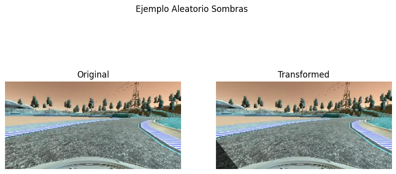

```python
# Ejemplo de la función apply_random_shadow aplicada sobre una imagen
imagen = cv2.imread('/content/TrainImagesTFM_1_2/IMG/center_2022_04_30_19_03_21_734.jpg')
ejemplo_sombras= apply_random_shadow(imagen)
resultado = compare_images(imagen, ejemplo_sombras, title='Ejemplo Aleatorio Sombras')
```

## Aumento aleatorio de imágenes

Haciendo uso de las funciones previas se puede generar una nueva función de aumento aleatorio que combina varias de las técnicas de aumento que se han venido revisando. Nuevamente es importante mencionar, que el siguiente código corresponde con una adaptación al trabajo de Sevilla Martínez

```python
import matplotlib.image as mpimg

def random_augment(image_path, steering_angle):
    """
    Aplica un conjunto de aumentos de manera aleatoria a la imagen y ajusta el ángulo de giro.

    Args:
        image_path: La ruta a la imagen que se va a aumentar.
        steering_angle: El ángulo de giro asociado con la imagen.

    Returns:
        La imagen aumentada y el ángulo de giro ajustado si es necesario.
    """
    # Cargar la imagen
    image = mpimg.imread(image_path)

    # Aplicar aumentos de manera aleatoria
    if np.random.rand() < 0.5:
        image = apply_pan(image)
    if np.random.rand() < 0.5:
        image = apply_zoom(image)
    if np.random.rand() < 0.5:
        image = apply_random_brightness(image)
    if np.random.rand() < 0.5:
        image = apply_image_brighten(image)
    if np.random.rand() < 0.5:
        image = apply_random_shadow(image)
    if np.random.rand() < 0.5:
        image, steering_angle = random_flip(image, steering_angle)

    return image, steering_angle
```

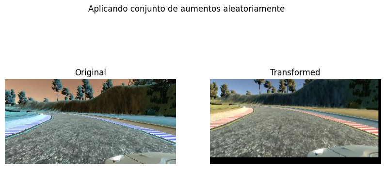

```python
# Ejemplo de la función random_augment aplicada sobre una imagen
imagen = image_paths[10]
ejemplo_random_aug, _ = random_augment(imagen,steerings[10])
resultado = compare_images(cv2.imread(imagen), ejemplo_random_aug, title='Aplicando conjunto de aumentos aleatoriamente')
```

## Generación de los datos para entrenar la red

Sevilla Martínez probó dos enfoques, crear un generador para proveer al modelo de las imágenes de entrenamiento o no hacerlo. A continuación, se reproduce la adaptación del código de los dos enfoques

```python
def img_preprocess(img):
    """
    Preprocesa la imagen para el entrenamiento del modelo CNN: recorte, conversión de espacio de color,
    desenfoque gaussiano, redimensionamiento y normalización.

    Args:
        img: Imagen de entrada como un arreglo de NumPy.

    Returns:
        Imagen preprocesada.
    """
    # Recortar la imagen para eliminar características innecesarias
    img = img[40:140, :, :]

    # Cambiar a espacio de color YUV
    img = cv2.cvtColor(img, cv2.COLOR_RGB2YUV)

    # Aplicar desenfoque gaussiano
    img = cv2.GaussianBlur(img, (3, 3), 0)

    # Reducir el tamaño para facilitar el procesamiento
    img = cv2.resize(img, (200, 66), interpolation=cv2.INTER_AREA)

    # Normalizar los valores de los píxeles
    img = (img - 128.) / 128.

    return img
```

```
WARNING:matplotlib.image:Clipping input data to the valid range for imshow with RGB data ([0..1] for floats or [0..255] for integers).
```

[figure not shown]

```python
# Ejemplo de la función img_preprocess aplicada sobre una imagen
imagen = cv2.imread('/content/TrainImagesTFM_1_2/IMG/center_2022_04_30_19_03_21_734.jpg')
ejemplo_pre_pro= img_preprocess(imagen)
resultado = compare_images(imagen, ejemplo_pre_pro, title='Ejemplo Preprocesamiento')
```

### Primer enfoque: Usando Generador de imágenes

```python
def batch_generator(image_paths, steering_angles, batch_size, is_training):
    """
    Genera lotes de imágenes y ángulos de dirección para entrenar un modelo.

    Args:
        image_paths: Lista de rutas a las imágenes.
        steering_angles: Lista de ángulos de dirección asociados con las imágenes.
        batch_size: Tamaño de los lotes a generar.
        is_training: Indica si el generador se utiliza para entrenamiento o validación.

    Yields:
        Un lote de imágenes y ángulos de dirección.
    """
    images = np.empty([batch_size, IMAGE_HEIGHT, IMAGE_WIDTH, IMAGE_CHANNELS])
    steers = np.empty(batch_size)
    while True:
        i = 0
        for index in np.random.permutation(len(image_paths)):
            image_path = image_paths[index]
            steering_angle = steering_angles[index]
            if is_training:
                # Solo aplicamos el aumento si estamos entrenando
                image, steering_angle = random_augment(image_path, steering_angle)
            else:
                # Si no estamos entrenando, solo leemos la imagen y no aplicamos aumentos
                image = mpimg.imread(image_path)
            # Aplicamos el preprocesamiento a la imagen
            image = img_preprocess(image)
            images[i] = image
            steers[i] = steering_angle
            i += 1
            if i == batch_size:
                break
        yield images, steers
```

```python
# De la siguiente forma la podemos invocamos la función
my_generator = batch_generator(X_train, y_train, batch_size=32, is_training=True)
validation_generator = batch_generator(X_valid, y_valid, batch_size=32, is_training=False)
```

### Segundo enfoque:

```python
# Como lo mencionó Sevilla Martínez consume una gran cantidad de RAM

import random

def normal_load(image_paths, steering_ang, batch_size, is_training):
    '''
    Carga las imágenes y los ángulos de dirección en la memoria RAM para el entrenamiento del modelo.
    Si es para entrenamiento, las imágenes pueden ser aumentadas aleatoriamente y preprocesadas.

    Args:
        image_paths: Lista de rutas a las imágenes.
        steering_ang: Lista de ángulos de dirección asociados con las imágenes.
        batch_size: Tamaño de los lotes a generar.
        is_training: Booleano que indica si es para entrenamiento y se deben aplicar aumentos.

    Returns:
        Lote de imágenes y ángulos de dirección como arrays de NumPy.
    '''
    while True:
      batch_img = []
      batch_steering = []

      for i in range (batch_size):
          random_index = random.randint(0, len(image_paths)-1)

          if is_training:
            if np.random.randint(6) == 0:
              im = mpimg.imread(image_paths[random_index])
              steering = steering_ang[random_index]
              im = img_preprocess(im)
              batch_img.append(im)
              batch_steering.append(steering)
            im, steering = random_augment(image_paths[random_index], steering_ang[random_index])

          else:
            im = mpimg.imread(image_paths[random_index])
            steering = steering_ang[random_index]

          im = img_preprocess(im)
          batch_img.append(im)
          batch_steering.append(steering)

      return (np.array(batch_img), np.array(batch_steering))
```

```python
train_images, train_steers = normal_load(X_train, y_train, len(X_train), is_training=True)
valid_images, valid_steers = normal_load(X_valid, y_valid, len(X_valid), is_training=False)
```

La ejecuión de este segundo enfoque tomó poco más de 4 minutos y utilizó 36 GB de memoria RAM en el entorno de Google Colab como se presenta en la siguiente imagen:

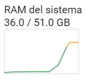

Finalizamos esta parte con una muestra de las imágenes guardadas en la memoria RAM:

```python
import matplotlib.pyplot as plt
import numpy as np

def show_images(images, cols=6, titles=None):
    """
    Muestra una lista de imágenes en una grilla con Matplotlib,
    asegurándose de que todas las imágenes estén en el rango de valores adecuado.

    Args:
        images: Lista o array de imágenes.
        cols: Número de columnas en la grilla de imágenes.
        titles: Lista de títulos para las imágenes, opcional.
    """
    assert((titles is None) or (len(images) == len(titles)))
    n_images = len(images)
    if titles is None: titles = ['Image (%d)' % i for i in range(1, n_images + 1)]
    fig = plt.figure(figsize=(2 * cols, 2 * int(np.ceil(n_images / cols))))
    for n, (image, title) in enumerate(zip(images, titles)):
        a = fig.add_subplot(int(np.ceil(n_images / cols)), cols, n + 1)
        if image.ndim == 2:  # Si es imagen en grises
            plt.gray()

        # Ajustar el rango de los datos de la imagen según su tipo
        if image.dtype == np.float32 or image.dtype == np.float64:
            # Para datos flotantes, se espera que estén entre 0 y 1
            if image.min() < 0 or image.max() > 1:
                image = np.clip(image, 0, 1)
        elif image.dtype == np.uint8:
            # Para datos enteros, se espera que estén entre 0 y 255
            if image.min() < 0 or image.max() > 255:
                image = np.clip(image, 0, 255)

        plt.imshow(image)
        a.set_title(title)
        plt.axis('off')
    plt.show()
```

```
51421
```

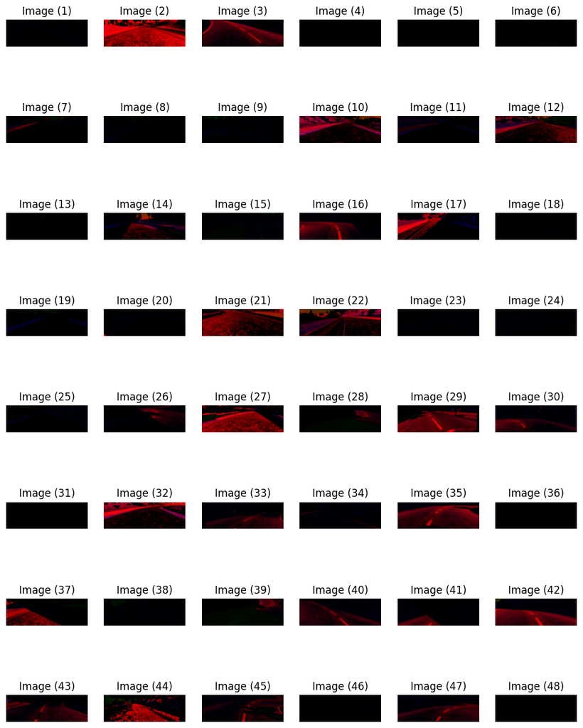

```python
# Mostrar las primeras 5 imágenes del array
print(len(train_images))
show_images(train_images[:48])
```